# Relatório 01 - Introdução ao Markdown e Latex

Alex Gama

10/09/2024

# 1 Objetivo:

Descrever as ideias básicas em relação a Markdown e Latex:

# 2 Markdown:

## 2.1 O que é o Markdown?

Markdown é uma linguagem de marcação, assim como o HTML. Ele é um jeito de escrever em texto puro, deixando anotações sobre a formatação. O Markdown é um sistema de formatação aberto que torna a escrita e a leitura mais simples. Com uma codificação mínima, além de fácil, ele é visualmente mais “limpo”.

## 2.2 Criando um arquivo

Para criar um arquivo em markdown, simplesmente salve com a extensão .md

## 2.3 Ferramentas

Para auxiliar a criação de arquivos markdown existem algumas, como:

- StackEdit
- Visual Studio Code
- Typora
- Dillinger
- Etc…

## 2.4 Usando o Markdown

O markdown é convertido em HTML, então se já tiver conhecimento de HTML é mais simples de absorver o conteúdo.

### 2.4.1 Comentários

Para criar comentários podemos usar a mesma sintaxe do html.

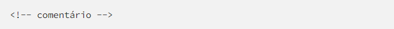

### 2.4.2 Title

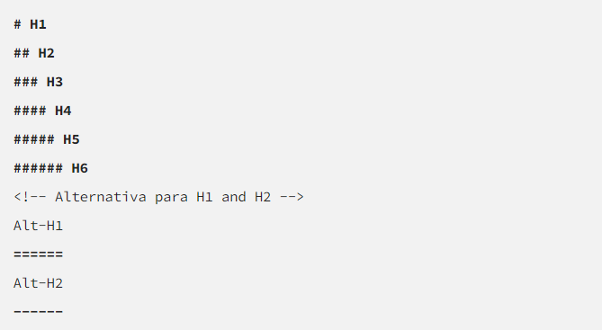

### 2.4.3 Lista

#### 2.4.3.1 Lista desordenada

Para criar uma lista não ordenada com o markdown podemos usar tanto *, quanto — ou +, todos têm a mesma funcionalidade, para criar uma sublista, apenas insira dois espaço ou um tab no item, exemplo:

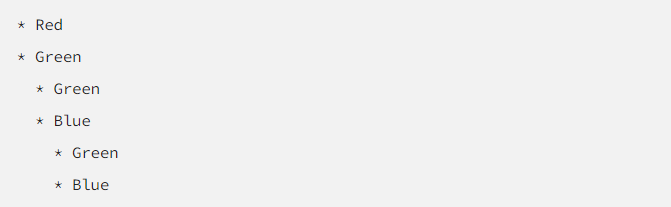

#### 2.4.3.2 Lista ordenada

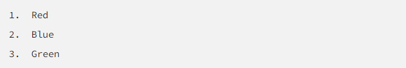

### 2.4.4 Lista de tarefas

Podemos criar também uma lista de tarefas, com a CheckBox preenchida ou não. Vejamos o exemplo:

**Comando**

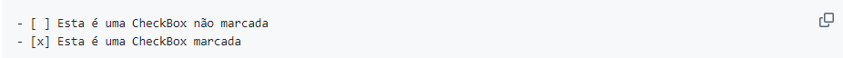

**Resultado do Comando**

- Esta é uma CheckBox não marcada
- Esta é uma CheckBox marcada

### 2.4.5 Links

É possível colocar algum link em seu ‘Readme’, e ainda colocá-lo por debaixo de uma palavra, é o chamado link-âncora, acessando-o ao clicar na palavra. Entre colchetes [ ] a palava que deseja por debaixo dos panos. E entre parentêses ( ) o link para acesso. Vejamos o exemplo do código:

**Comando**

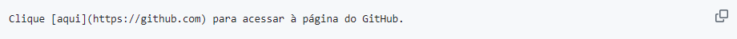

**Resultado do Comando**

Clique [aqui](https://github.com) para acessar à página do GitHub.

Para links sem uma palavra por cima do link, use ‘< >’ para envolver o link desejado, assim o link aparecerá por inteiro ao leitor. Exemplo:

**Resultado do Comando**

https://google.com.br

### 2.4.6 Como adicionar imagens no Markdown?

Comandos: (interno a < > colocamos: img src = “logo”) ou utilizamos o comando “Ponto de exclamação!, colchetes [figura 1 ] e (imagem)”.

Adicionando imagens

Para adicionar uma imagem a um documento, adicione seu arquivo de imagem à pasta do documento (neste exemplo nosso, esta na pasta rel01) e, em seguida, faça referência à imagem no arquivo index.md do documento usando os símbolos < > e internamente aos símbolos use: img src = ufsj.png. Ou a sintaxe Markdown equivalente (Ou seja, existem outras formas de inserir imagens no Markdown).

### 2.4.7 Como adicionar tabelas

Escolha os títulos das colunas e use *|* para delimitar as colunas. Depois, utilize hífen - na segunda linha para indicar que acima estão os títulos das colunas, usando novamente o *|* para delimitar colunas. Veja um exemplo abaixo:

**Comando dado:**

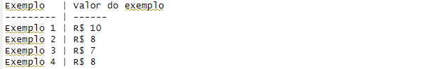

**Resultado do Comando:**

| Exemplo | Valor do exemplo |
| --- | --- |
| Exemplo 1 | R$ 10 |
| Exemplo 2 | R$ 8 |
| Exemplo 3 | R$ 7 |
| Exemplo 4 | R$ 8 |

### 2.4.8 Estilo de texto

O markdown possui diversas formas de ajustar o texto.

#### 2.4.8.1 **Texto em negrito**

Para usar texto negrito use dois asteriscos **(dois asteriscos antes do texto e dois depois do texto)**.

#### 2.4.8.2 **Texto em italico**

Para usar texto itálico use um underscore (_) ou só um asterisco(*).(*um antes do texto e o outro depois do texto*)

#### 2.4.8.3 **Texto riscado**

Para usar texto riscado use dois til.(uma antes do texto e outro depois do texto)

#### 2.4.8.4 **Texto sobrescrito**

Para usar texto sobrescrito é necessário usar a tag < sup > antes da palavra e depois dela.

Texto <sup>sobrescrito</sup>

#### 2.4.8.5 **Texto subscrito**

Para usar texto subscrito é necessário usar a tag < sub > antes da palavra e depois dela.

Texto <sub>subscrito</sub>

#### 2.4.8.6 **Texto marcado**

Para marcar um texto podemos usar a tag < mark >,antes do texto ou palavra.

Texto marcado

### 2.4.9 Usando fórmulas matemáticas

Para usar fórmulas de matemática use o dólar ($) antes e depois da fórmula que desejar exibir, como o exemplo dado.

**Resultado do comando**

$-b \pm \sqrt{b² — 4ac} \over 2a$

# 3 Latex

## 3.1 Por que aprender Latex

LaTeX é usado em todo o mundo para documentos científicos, livros, bem como muitas outras formas de publicação. Não só ele pode criar lindamente documentos impressos, mas também permite que os usuários abordem rapidamente as partes mais complicadas da composição, como inserir matemática, criar tabelas de conteúdo, fazer referência e criar bibliografias e ter um layout consistente em todas as seções. Devido ao grande número de pacotes open source disponíveis, as possibilidades com LaTeX são infinitas. Estes pacotes permitem que os usuários façam ainda mais com o LaTeX, como adicionar notas de rodapé, desenhar esquemas, criar tabelas etc. Uma das razões mais importantes pelas quais as pessoas usam o LaTeX é que ele separa o conteúdo do documento do seu estilo. Isso significa que, depois de ter escrito o conteúdo do seu documento, podemos alterar sua aparência com facilidade. Da mesma forma, você pode criar um estilo de documento que pode ser usado para padronizar a aparência de muitos documentos diferentes. Isso permite que periódicos científicos criem modelos para envios. Esses modelos têm um layout pré-feito, o que significa que apenas o conteúdo precisa ser adicionado. Na verdade, existem centenas de modelos disponíveis para tudo, desde currículos até apresentações de slides.

## 3.2 Corpo do documento

• Comandos Globais: definições aplicadas em todo documento, que constituem o Preâmbulo;

## 3.3 Comandos básicos

• article: documentos curtos e artigos.

• report: documentos longos, com sec¸c˜oes e cap´ıtulos, como teses e dissertações.

• book: produção de livros.

• letter: cartas.

Em opções, escolhemos além do tamanho da fonte e do tipo de folha a ser impressa, outras caracteristicas como:

• twoside: impressão em ambos os lados da página, sendo que a margem para encadernação estará à esquerda, no caso de páginas ímpares, e à direita nas páginas pares.

• oneside: impressão em um só lado da página.

• twocolumn: o documento será formatado em duas colunas.

Exemplo 1 O comando

`\documentclass[12pt,a4paper,twoside]{article}`

indica que o nosso texto será formatado com letra no tamanho 12pt, impresso em folha A4 e no modo frente e verso.

Além das características do comando documentclass, podemos adicionar no preâmbulo do arquivo alguns pacotes que podem aprimorar o texto que desejamos digitar. Por exemplo:

`\usepackage[latin1]{inputenc}` (Habilita o uso de acentos diretamente do teclado.)

`\usepackage[brazil]{babel}` (Editor flexível quanto à escolha do idioma.)

`\usepackage{graphicx}` (Permite incluir figuras e colorir o texto)

`\usepackage{color}` (Permite colorir o texto)

`\usepackage{amsmath}` (Habilita as funções do modo matemático)

`\usepackage{amsfonts}` (Estilos de letras para o ambiente matemático)

`\usepackage{amssymb}` (Habilita a utilização de símbolos)

Com base nestes novos comandos, podemos montar um preâmbulo mais refinado, onde será possível formatar textos mais complexos, como por exemplo, textos com caracteres matemáticos, figuras, tabelas, dentre outros.

## 3.4 Estrutura básica

`\documentclass[12pt,a4paper,twoside]{article}`

`\usepackage[latin1]{inputenc}`

`\usepackage[brazil]{babel}`

`\usepackage{amsmath}`

`\usepackage{amsfonts}`

`\usepackage{amssymb}`

`\begin{document}`

`\end{document}`

O texto que desejamos escrever, deve ser inserido entre os comandos `\begin{document}` e `\end{document}`, que determinam, respectivamente, o começo e o fim do documento. Tais comandos são obrigatórios e, como já destacado anteriormente, são parte da exigência mínima para que um software de edição de arquivos no formato LATEX gere determinado documento. Cabe destacar, que qualquer caracter colocado após o comando `\end{document}`, será ignorado pelo software.

Exemplo 2:

Se no arquivo LATEX escrevermos exatamente como abaixo:

`\begin{document}`

“A Matemática não mente. Mente quem faz mau uso dela.” (Albert Einstein)

`\end{document}`

“Na teoria da relatividade, não existe tempo absoluto único; em vez disso, cada indivíduo tem sua própria medida de tempo, que depende de onde ele se encontra e de como está se movendo” (Stephen Hawking)

quando compilarmos, visualizaremos:

“A Matemática não mente. Mente quem faz mau uso dela.”(Albert Einstein)

Para utilizar a Estrutura básica 3.4, inicialmente abra o programa TeXnicCenter, ou outro software de sua preferência, e crie um documento clicando na aba File, selecionando a opção New e, em seguida, a opção File. Por fim, basta copiar os camandos da estrutura e compilar o arquivo (Ctrl + Shift + F 5).

## 3.5 Formatação

### 3.5.1 Formatação de páginas

Para a formatação da página em relação ao dimensionamento da folha, usamos no preâmbulo o seguinte comando:

`\usepackage{geometry}`

`\geometry{paperwidth=210mm,paperheight=297mm, textwidth=160mm,textheight=210mm,top=30mm, bottom=20mm,left=30mm,right=20mm}`

Cada parâmetro de dimensionamento citado acima, tem o significado como descrito na Tabela 2.1.

### 3.5.2 Estilos e tamanhos de letras

No LATEX podemos alterar tanto o estilo quanto o tamanho da letra, através de comandos locais.

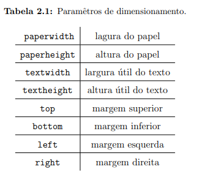

### 3.5.3 Estilos

As palavras podem ser sublinhadas ou destacadas em negrito, itálico, entre outros,como descrito abaixo.

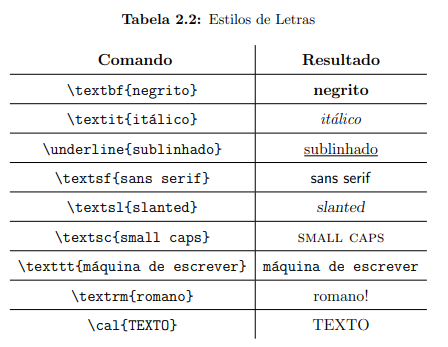

### 3.5.4 Tamanho

Para redefinir o tamanho da letra utilizada em uma ´única palavra, fazemos uso dos comandos em destaque na seguinte tabela.

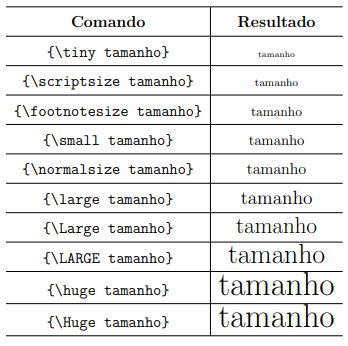

### 3.5.5 Caracteres especiais

No LATEX , existem carecteres especiais que para serem gerados é necessária a utilização de uma barra “”, como mostrado a seguir.

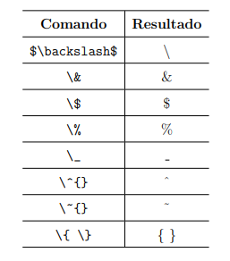

Tais caracteres são especiais pois, se não colocarmos a barra antes deles, estes caracteres funcionam como parte de comandos que já são pré-estabelecidos pelo software. Por exemplo, o caracter “&” é utilizado para delimitar colunas em tabelas e matrizes,enquanto o caracter “ _ ” é usado para fazer subíndices de uma sequência como a<sub>i<sub>.</sub></sub>

### 3.5.6 Comentários

O que for colocado à direita de “%” é um comentário e o LATEX não o considera no documento de saída.

Abaixo colocamos três comentários ultilizando o caracter “%”

`\begin{document}` %início do documento.

O único homem que está isento de erros, é aquele que não arrisca acertar. (Albert Einstein) %texto.

`\end{document}` %fim do documento.

que quando compilados, os mesmos não aparecerão no documento:

O único homem que está isento de erros, é aquele que não arrisca acertar. (Albert Einstein)

### 3.5.7 Espaçamentos, quebras de páginas e linhas

#### 3.5.7.1 Espaçamentos

No LATEX espaços consecutivos são ignorados e não são inseridos no documento de saída.

Escrevendo:

Hoje vamos aprender a derivar!

Resultará em:

Hoje vamos aprender a derivar!

Para que o LATEX reconheça os espaços devemos colocar barras invertidas “” separadas por espaços.

Quando digitarmos:

Teremos:

Hoje vamos derivar!

Ainda, é possível alterar o tamanho dos espaços em branco através dos comandos:

`\vspace{medida em centímetros}` (Espaçamento vertical).

`\hspace{medida em centímetros}` (Espaçamento horizontal).

A frase:

Cálculo Diferencial e Integral, foi gerada a partir de Cálculo `\hspace{2cm}` Diferencial`\hspace{2cm}` e `\hspace{2cm}` Integral.

#### 3.5.7.2 Quebra de páginas

# 4 Conclusões

A partir deste relatório tivemos a oportunidade de depararmos com duas ferramentas que nos auxiliará em muito na elaboração do trabalho ciêntifico apresentado no final do curso.Nos familiarizamos e tivemos um primeiro contato com a estrutura básica e os principais comandos de cada uma das ferramentas. Dado maior enfase ao Markdown por se tratar da confecção dos relátorios entregues na disciplina de Estatística.